# Introduction to phoenics

Camille Guilmineau, Rémi Servien et Nathalie Vialaneix

2025-08-19

# Introduction

`phoenics` is an **R** package designed to perform a differential analysis for metabolomics datasets, while accounting for metabolomic pathway information. More precisely, `phoenics` performs a test at pathway level based on metabolite quantifications and information on pathway metabolite composition. The automatic query of metabolic pathways is implemented in the package. See Guilmineau *et al.*, 2025.

```r
library("phoenics")
```

# MTBLS422 dataset

The dataset `MTBLS422` contains data obtained from the study Choo *et al.*, 2017. Raw data have been made available on MetaboLights (with the id MTBLS422 https://www.ebi.ac.uk/metabolights/editor/MTBLS422). Metabolite quantifications were obtained based on the raw signal using [ASICS](https://www.bioconductor.org/packages/release/bioc/html/ASICS.html) package and are provided in the object `quantif` included in the dataset.

```r
data("MTBLS422")
ls()
```

```
## [1] "design"   "pathways" "quantif"
```

```r
head(quantif)
```

```
##                              1071        1151 1231        1281        1371
## Glycerol              0.000000000 0.000000000    0 0.000000000 0.000000000
## D-Glucose-6-Phosphate 0.002339491 0.001251202    0 0.001958586 0.002652924
## D-Galactose           0.001628629 0.003448431    0 0.001535844 0.002693243
## D-Sorbitol            0.000000000 0.000000000    0 0.000000000 0.000000000
## Myo-Inositol          0.001190331 0.001929542    0 0.001325843 0.001760645
## D-GlucuronicAcid      0.001495646 0.003459446    0 0.001377114 0.001855756
##                              1531         1681         1751        2081
## Glycerol              0.001403664 0.0000000000 0.0008294523 0.000000000
## D-Glucose-6-Phosphate 0.002877861 0.0035782998 0.0025688724 0.002273193
## D-Galactose           0.001952493 0.0037286043 0.0000000000 0.001240772
## D-Sorbitol            0.001066357 0.0009889747 0.0012056168 0.000000000
## Myo-Inositol          0.001430719 0.0028295101 0.0011248417 0.002085898
## D-GlucuronicAcid      0.001791299 0.0007645118 0.0000000000 0.001816359
##                              2161        2311
## Glycerol              0.000000000 0.000000000
## D-Glucose-6-Phosphate 0.001106493 0.002437845
## D-Galactose           0.002072136 0.001392737
## D-Sorbitol            0.000000000 0.000000000
## Myo-Inositol          0.001382456 0.001893727
## D-GlucuronicAcid      0.002410063 0.001502470
```

They can be transformed into a data format suitable for `phoenics` with:

```r
quantif_f <- from_ASICS_to_PHOENICS(quantif)
head(quantif_f)
```

```
##           C00116      C00092      C00984      C00794      C00137      C00191
## 1071 0.000000000 0.002339491 0.001628629 0.000000000 0.001190331 0.001495646
## 1151 0.000000000 0.001251202 0.003448431 0.000000000 0.001929542 0.003459446
## 1231 0.000000000 0.000000000 0.000000000 0.000000000 0.000000000 0.000000000
## 1281 0.000000000 0.001958586 0.001535844 0.000000000 0.001325843 0.001377114
## 1371 0.000000000 0.002652924 0.002693243 0.000000000 0.001760645 0.001855756
## 1531 0.001403664 0.002877861 0.001952493 0.001066357 0.001430719 0.001791299
##            C00864       C01697       C00029       C00003
## 1071 0.0005098139 0.0000000000 0.0005008620 0.0000000000
## 1151 0.0007075218 0.0005573846 0.0000000000 0.0000000000
## 1231 0.0000000000 0.0000000000 0.0000000000 0.0009024399
## 1281 0.0004129427 0.0005796955 0.0004431261 0.0000000000
## 1371 0.0007317685 0.0005080792 0.0000000000 0.0000000000
## 1531 0.0002865527 0.0000000000 0.0006293917 0.0000000000
```

In addition, pathway information was obtained using [KEGGREST](https://www.bioconductor.org/packages/release/bioc/html/KEGGREST.html) package and is included in `pathways`:

```r
head(pathways)
```

```
##    metabolite_code   metabolite_name pathway_code         pathway_name
## 24          C00029       UDP-glucose     mmu00052 Galactose metabolism
## 25          C00116          Glycerol     mmu00052 Galactose metabolism
## 26          C00137      myo-Inositol     mmu00052 Galactose metabolism
## 27          C00794        D-Sorbitol     mmu00052 Galactose metabolism
## 28          C00984 alpha-D-Galactose     mmu00052 Galactose metabolism
## 29          C01697        Galactitol     mmu00052 Galactose metabolism
```

The user can also query this information using the function `pathway_search`:

```r
pathways <- pathway_search(metab = colnames(quantif), organism = "mmu")
```

# `phoenics` test

## Perform test

The test implemented in `phoenics` is a mixed model with fixed and random effects. The current study design is provided in `design`:

```r
head(design)
```

```
##           Id Age Treatment Mouse
## 1071 T1_G1R1 5.5   Control  G1R1
## 1151 T1_G1R2 5.5   Control  G1R2
## 1231 T2_G1R2 7.5   Control  G1R2
## 1281 T2_G1R1 7.5   Control  G1R1
## 1371 T1_G3R2 5.5 Vanco-Imi  G3R2
## 1531 T3_G1R1 9.0   Control  G1R1
```

The `Age` and `Treatment` are thus used as fixed effects and the `Mouse` is used as a random effect:

```r
out_test <- test_pathway(quantif_f, design, pathways,
                         fixed = c("Age", "Treatment"), random = "Mouse",
                         npc = 2, model = "blmer")
out_test
```

```
## phoenics method based on PCA
## A list of pathways which contains for each pathway:
## $pathway_name: Pathway name
## $pathway_code: Pathway code
## $metabolites: Metabolites in the pathway
## $PCA: Factor analysis results
## $model: Model results
## $test_pathway: Pathway test results
```

## Access test results

Results are organized as a list where each element of the list corresponds to a tested pathway:

```r
names(out_test)
```

```
## [1] "Galactose metabolism"             "Inositol phosphate metabolism"
## [3] "Vitamin digestion and absorption"
```

The function `extract` can be used to extract results on a given pathway:

```r
res_1 <- extract(out_test, "Galactose metabolism")
```

Fixed effect $p$-values and full model are provided, respectively, in entries `test_pathway` and `model` of this object.

```r
res_1[[1]]$test_pathway
```

```
##   Fixed_effect      pval
## 1          Age 0.2145888
## 2    Treatment 0.3831807
```

```r
res_1[[1]]$model
```

```
## $mmu00052_PC1
## Cov prior  : Mouse ~ wishart(df = 3.5, scale = Inf, posterior.scale = cov, common.scale = TRUE)
## Prior dev  : -0.6945
##
## Linear mixed model fit by REML ['blmerMod']
## Formula: mmu00052_PC1 ~ Age + Treatment + (1 | Mouse)
##    Data: score_path
## REML criterion at convergence: 40.441
## Random effects:
##  Groups   Name        Std.Dev.
##  Mouse    (Intercept) 2.054
##  Residual             1.629
## Number of obs: 11, groups:  Mouse, 4
## Fixed Effects:
##        (Intercept)                 Age  TreatmentVanco-Imi
##             2.0008             -0.3463              1.1450
##
## $mmu00052_PC2
## Cov prior  : Mouse ~ wishart(df = 3.5, scale = Inf, posterior.scale = cov, common.scale = TRUE)
## Prior dev  : -1.996
##
## Linear mixed model fit by REML ['blmerMod']
## Formula: mmu00052_PC2 ~ Age + Treatment + (1 | Mouse)
##    Data: score_path
## REML criterion at convergence: 36.1712
## Random effects:
##  Groups   Name        Std.Dev.
##  Mouse    (Intercept) 2.209
##  Residual             1.136
## Number of obs: 11, groups:  Mouse, 4
## Fixed Effects:
##        (Intercept)                 Age  TreatmentVanco-Imi
##            -3.1797              0.3949              0.5002
```

```r
adjust_pval(out_test)
```

```
##                       pathway_name pathway_code Fixed_effect        pval
## 1             Galactose metabolism     mmu00052          Age 0.214588838
## 3    Inositol phosphate metabolism     mmu00562          Age 0.037233449
## 5 Vitamin digestion and absorption     mmu04977          Age 0.009257926
## 2             Galactose metabolism     mmu00052    Treatment 0.383180685
## 4    Inositol phosphate metabolism     mmu00562    Treatment 0.485524008
## 6 Vitamin digestion and absorption     mmu04977    Treatment 0.419680043
##   adjusted_pval
## 1    0.21458884
## 3    0.07446690
## 5    0.02777378
## 2    1.00000000
## 4    1.00000000
## 6    1.00000000
```

## Explore PCA results

PCA results can be explored using the entry PCA:

```r
res_1[[1]]$PCA
```

[output not shown]

In particular, `phoenics` implements some plots that can be directly obtained using

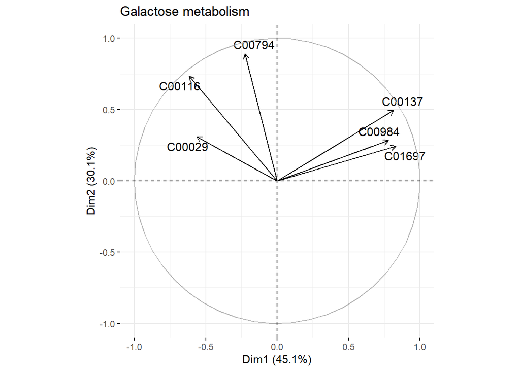

```r
plot(out_test, pathway_id = "Galactose metabolism", plot = "var")
```

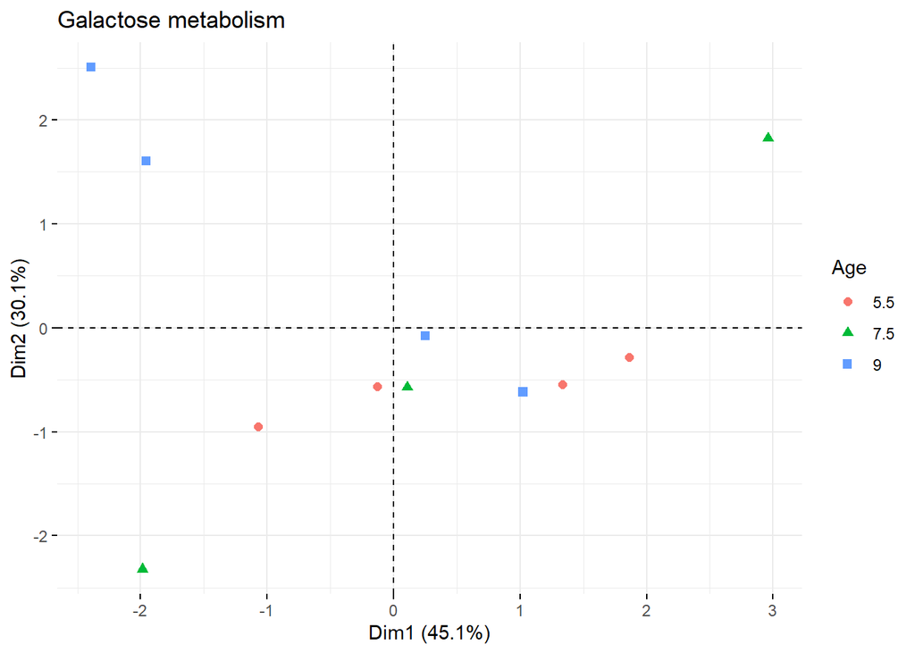

```r
plot(out_test, pathway_id = "Galactose metabolism", plot = "ind",
     habillage = "Age")
```

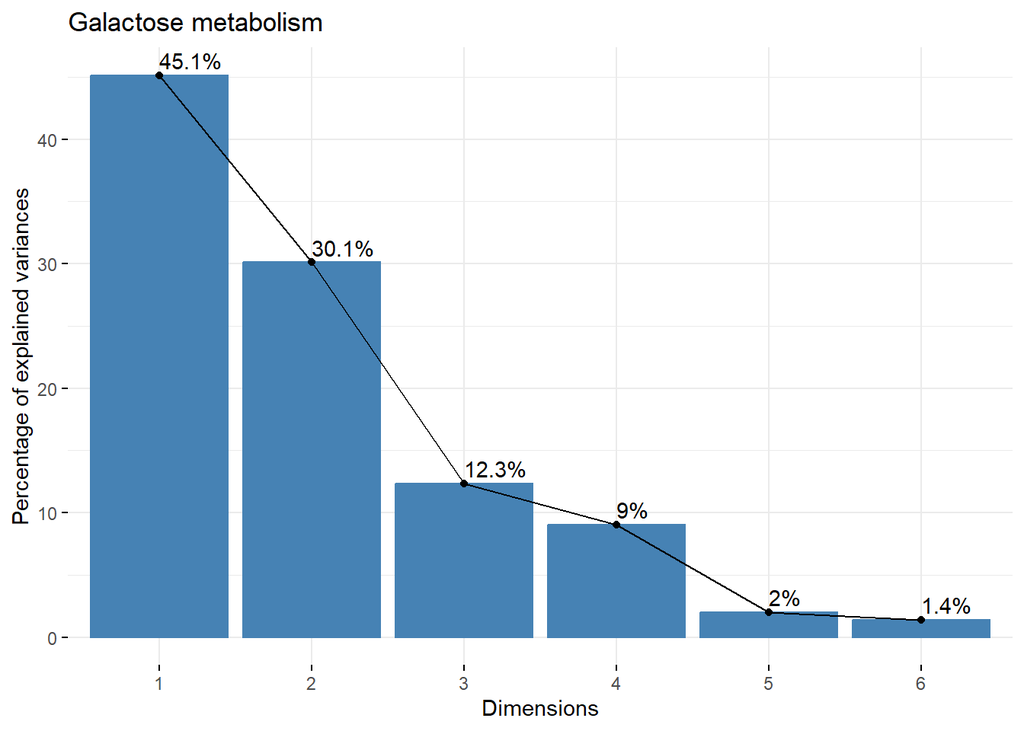

```r
plot(out_test, pathway_id = "Galactose metabolism", plot = "eig")
```

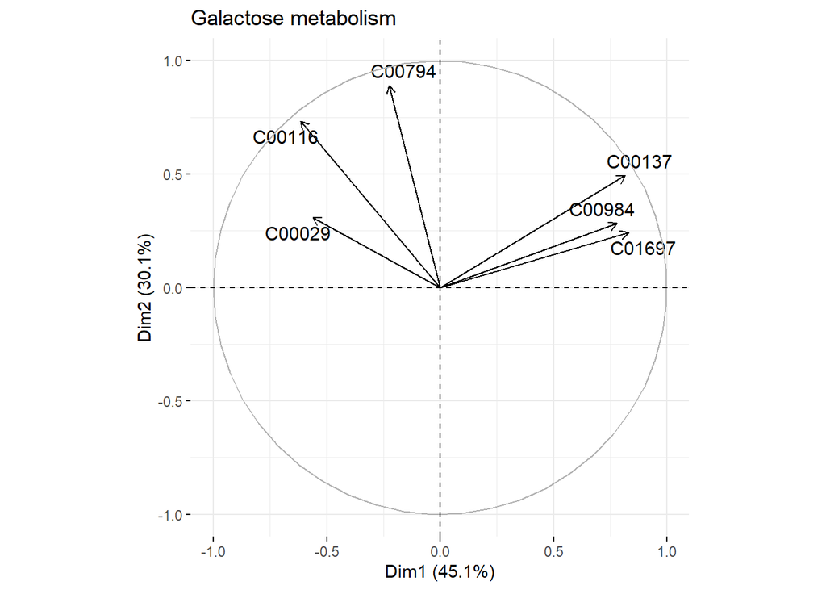

```r
plot(out_test, pathway_id = "Galactose metabolism", plot = "var")
```

```r
plot(out_test, pathway_id = "Galactose metabolism", plot = "group")
```

[output not shown]

# Options of `phoenics` main test function

## Switching from PCA to MFA

A MFA step, more suited to can be used in place of the PCA. In this case, the levels first fixed effect are used to split the effects into different tables which are matched by the levels of the first random effect (the typical case is when the first fixed effect contains information on time points in a repeated measurement study where samples are provided by the first random effect).

```r
out_test <- test_pathway(quantif_f, design, pathways,
                         fixed = c("Age", "Treatment"), random = "Mouse",
                         npc = 2, model = "blmer", analysis = "MFA")
```

[output not shown]

```r
out_test
```

```
## phoenics method based on MFA
## A list of pathways which contains for each pathway:
## $pathway_name: Pathway name
## $pathway_code: Pathway code
## $metabolites: Metabolites in the pathway
## $PCA: Factor analysis results
## $model: Model results
## $test_pathway: Pathway test results
```

## Wrapper to automatically query pathways

```r
out_test3 <- test_pathway(quantif, design, pathways = "auto",
                          fixed = c("Age", "Treatment"), random = "Mouse",
                          npc = 2, model = "blmer", organism = "mmu")
out_test3
```

# References

[1] Guilmineau, C., Tremblay-Franco, M., Vialaneix, N., & Servien, R. (2025). phoenics: a novel statistical approach for longitudinal metabolomic pathway analysis. *BMC Bioinformatics*, **26**: 105. DOI: 10.1186/s12859-025-06118-z.

[2] Choo J. M., Kanno T., Zain N. M. M., Leong L. E. X., Abell G. C. J., Keeble J. E., Bruce K. D., Mason A. J., Rogers G. B. (2017). Divergent relationships between fecal microbiota and metabolome following distinct antibiotic-induced disruptions. *mSphere*, **2**(1). DOI: 10.1128/msphere.00005-17.

[3] Benjamini Y, Hochberg Y (1995). Controlling the false discovery rate: a practical and powerful approach to multiple testing. *Journal of the Royal Statistical Society, Series B*, **57**(1): 289–300. DOI: 10.1111/j.2517-6161.1995.tb02031.x